# Contrasting Climate–Yield Response Patterns of Rainfed Maize Across Sub-Saharan African Agroecological Zones

2025-05-28

# Introduction

This script performs a comprehensive analysis of agricultural yield data across different Agro-Ecological Zones (AEZs) in Sub-Saharan Africa. It uses the *tidymodels* framework and bootstrap resampling to estimate uncertainty in predictions and feature importance. The code is organized for clarity and reproducibility, with settings controlled via YAML configuration files and results saved in structured outputs.

The purpose of the script is to identify and explain the key climate and soil factors that drive yield variability across regions. We model maize yield as a function of several climate variables to understand how seasonal weather patterns influence productivity.

$$\begin{aligned}
\text{Yield (kg/ha)} = f(& \text{Total rainfall, Rainfall deviation,
Longest dry spell,} \\
& \text{Fraction rainy days, Rainy days
deviation,} \\
& \text{Avg. max temperature, Max
temperature deviation})
\end{aligned}$$

Random Forests are used for their ability to model nonlinear relationships and variable interactions without requiring extensive tuning. SHAP (SHapley Additive exPlanations) values provide interpretable estimates of feature contributions to individual predictions, allowing visualization of the estimated functional relationship between climate factors and maize yield. Bootstrap resampling adds robustness by quantifying uncertainty around model performance and variable importance.

No tuning is done in this script for simplicity and saving data. The parameter tuning was done previously in the *workflow.R* script using a Cross-Validation Grid Search scheme.

# Script Structure and Workflow

The script follows a structured workflow to analyze agricultural data across multiple AEZs:

## 1. Initialization

```r
# Create logs directory
dir.create("logs", recursive = TRUE, showWarnings = FALSE)

# Load required libraries
library(tidymodels)
library(tidyverse)
library(vip)
library(yaml)
library(plotly)
```

The script begins by creating a logs directory and loading essential R packages. It then sources numerous custom R functions stored in the `R/` directory that handle specific tasks like data preprocessing, model training, and visualization.

## 2. Configuration and Setup

```r
# Get command line arguments
args <- commandArgs(trailingOnly = TRUE)
experiment <- args[1]
AEZ <- args[2]

# Define AEZ list
AEZ_list <- c("Warm.Semiarid", "Warm.Subhumid", "Warm.Humid",
              "Cool.Semiarid", "Cool.Subhumid", "Cool.Humid")

# Feature mapping for better interpretability
feature_mapping <- c(
  "Rain.Days.L.1" = "Fraction_Rainy_Days",
  "Mean_clay_tot_psa" = "Clay",
  "Mean_sand_tot_psa" = "Sand",
  "Mean_ecec.f" = "ECEC",
  "Mean_OC" = "OC",
  "Presowing.Rain.sum" = "Presowing_Rainfall",
  "Rain.sum" = "Total_Rainfall",
  "Rain.sum.Dev.Mean" = "Total_Rainfall_Dev",
  "Tmax.mean" = "Avg_Max_Temp",
  "Rain.Days.L.1.Dev.Mean" = "Fraction_Rainy_Days_Dev",
  "Rain.Max.RSeq.5" = "Longest_Dry_Spell",
  "Tmax.mean.Dev.Mean" = "Avg_Max_Temp_Dev",
  "yield" = "Yield"
)
```

The script accepts command-line arguments for the experiment name and optionally an AEZ to analyze. It defines a list of all AEZs to analyze and creates a feature mapping to convert technical variable names to more readable names.

## 3. Data Processing and Analysis

The main part of the script contains a loop that processes each AEZ (Agro-Ecological Zone) one by one. For clarity, we’ll examine the core components of this processing without repeating the loop structure.

### Configuration and Parameter Setup

```r
# In the full script, this code is inside an AEZ loop
# Manual settings for experiment name
experiment <- "no_outliers_eco_isqrt_nosoil"
experiment_t <- experiment  # Tracking original experiment name

# Default AEZ if none specified
AEZ <- "Warm.Semiarid"

# Load configuration from YAML file
config <- yaml::read_yaml(paste0("config/", experiment, "_config.yaml"))

# Set parameters for analysis
create_colour_features <- TRUE  # Whether to create categorical feature indicators
create_plotly <- TRUE  # Whether to create interactive plots
n_bootstraps <- 99  # Number of bootstrap iterations for uncertainty quantification

# Initialize data structures to store results
# These will hold metrics and SHAP values for all bootstrap iterations
bootstrap_results <- list(
  train_metrics = list(),  # Performance on training data
  oob_metrics = list(),    # Out-of-bag performance
  test_metrics = list(),   # Performance on test data
  MDA_importance = list(), # Mean Decrease in Accuracy importance
  shap_values = list()     # SHAP values for all features
)

# Similar structure for the full (non-bootstrapped) model
full_results <- list(
  train_metrics = list(),
  oob_metrics = list(),
  test_metrics = list(),
  MDA_importance = list(),
  shap_values = list()
)
```

### Formula and Parameter Extraction

This part obtaines the parameters of the analysis from the config file.

```r
# Extract parameters from configuration
data_path <- config$data_path    # Path to input data
target <- config$target          # Target variable name (e.g., "yield")

# Process the formula specified in the config
# 1. Clean up whitespace and quotes
formula_string <- gsub("\\s+", " ", config$general_formula)
formula_string <- gsub('"', '', formula_string)
formula_string <- trimws(formula_string)

# 2. Convert to formula object
general_formula <- as.formula(formula_string)

# 3. Apply feature mapping for readability (e.g., "Rain.sum" → "Total_Rainfall")
general_formula <- remap_formula(formula_string, feature_mapping)

# Extract other configuration settings
weighted <- config$weighted                                # Whether to use weighted sampling
imputation_method <- config$preprocessing$imputation_method # Method for handling missing values
lower_quantile <- config$preprocessing$lower_quantile      # Remove outliers below this quantile
upper_quantile <- config$preprocessing$upper_quantile      # Remove outliers above this quantile
train_prop <- config$splits$train_prop                     # Proportion for train/test split
n_cv_folds <- config$splits$cv_folds                       # Number of cross-validation folds
cv_seed <- config$splits$seed                              # Random seed for reproducibility
```

### Data Loading and Preprocessing

```r
# Load and preprocess data
data <- load_and_preprocess(
  data_path = data_path,         # Input data file path
  target_col = target,           # Target variable (e.g., "yield")
  cols_to_remove = NULL,         # Columns to exclude (none specified)
  imputation_method = imputation_method, # Method for handling missing values
  lower_quantile = lower_quantile,       # Filter outliers
  upper_quantile = upper_quantile        # Filter outliers
)

# Create a summary of observations per AEZ for reporting
N_obs_table <- data %>% select(AEZ16simple) %>% table()
AEZ_table_names <- names(N_obs_table)
N_obs_df <- data.frame(
  AEZ = AEZ_list,
  N_obs = as.numeric(N_obs_table[AEZ_list])
)

# Create visualization of AEZ distribution in the dataset
plot_aez_distribution(data, experiment)

# Apply feature mapping to data columns
# This replaces technical names with more readable ones
existing_cols <- names(feature_mapping)[names(feature_mapping) %in% names(data)]
data <- data %>%
  rename(!!!setNames(existing_cols, feature_mapping[existing_cols]))
target <- str_replace_all(target, feature_mapping)

# Extract feature list from formula and normalize data
feature_list <- all.vars(general_formula)[-1]  # All variables except target
normalized_data <- normalize_features(data, feature_list)

# Filter data for the current AEZ
# In the full script, this happens inside the AEZ loop
data <- data %>%
  filter(AEZ16simple == AEZ)
experiment <- paste0(experiment, "_", AEZ)  # Update experiment name with AEZ
```

### Model Preparation and Training

This part sets up weights and weight functions and splits the data into training and testing.

```r
# The script focuses on Random Forest (model_i = 2 in the config)
model_i <- 2

# Log-transform the target if needed
if (config$models[[model_i]]$recipe_options$transformations) {
  data[[target]] <- log(data[[target]] + 1)
}

# Handle weights for sampling if configured
if (weighted) {
  # Add case_weights to the formula
  general_formula <- update(general_formula, . ~ . + case_weights)

  # Create weight_ID by combining site, year, and season
  data <- data %>%
    mutate(weight_ID = paste(Site.Key, M.Year, Season, sep = "_"))

  # Get the appropriate weighting function based on config
  weight_func <- assign_weight_function(config$weighted_method)
}

# Split data into training and testing sets
set.seed(cv_seed)
init_split <- initial_split(
  data,
  prop = 0.8,               # 80% for training, 20% for testing
  strata = !!sym(target)    # Stratify by the target variable
)
train_data <- training(init_split)
test_data <- testing(init_split)

# Add weights to training data if needed
if (weighted) {
  train_data <- train_data %>%
    mutate(
      # Calculate weights based on selected weighting method
      case_weights = weight_func(train_data, "weight_ID"),
      case_weights = importance_weights(case_weights)  # Convert to importance weights
    )
}
```

### Recipe Creation and Model Training

A recipe is created for model training and the Random Forest model is trained.

```r
# Create recipe for data preprocessing
recipe <- create_recipe(
  data = train_data,
  formula = general_formula,
  # Pass through options from config
  one_hot = config$models[[model_i]]$recipe_options$one_hot,             # Convert categoricals to binary
  standardize = config$models[[model_i]]$recipe_options$standardize,     # Standardize numerics
  normalize = config$models[[model_i]]$recipe_options$normalize,         # Normalize instead of standardize
  augment = config$models[[model_i]]$recipe_options$augment,             # Add derived features
  variable_selection = config$models[[model_i]]$recipe_options$variable_selection, # Feature selection
  parallel = config$models[[model_i]]$recipe_options$parallel            # Use parallel processing
)

# Prepare the recipe and transform the data
prepped_recipe <- prep(recipe, training = train_data)
transformed_data <- bake(prepped_recipe, new_data = NULL)  # NULL means use training data

# Train a Random Forest model on the full training dataset
final_workflow <- train_simple_rf(
  data = train_data,
  target_col = target,
  formula = general_formula,
  rec = recipe,
  mtry = 3,              # Number of variables considered at each split
  trees = 1000,          # Number of trees in the forest
  min_n = 25,            # Minimum node size
  max.depth = 7          # Maximum tree depth
)
```

### Model Evaluation and Feature Importance

The model performance is evaluated and variable importance (MDA) is estimated.

```r
# Calculate performance metrics on training and test data
all_metrics <- estimate_metrics_simple_rf(
  final_workflow,
  train_data,
  test_data,
  target_col = target
)

# Calculate variable importance using permutation
variable_importance <- calculate_variable_importance(
  trained_workflow = final_workflow,
  model_name = config$models[[model_i]]$name,
  output_dir = paste0("outputs/", experiment, "/full_results/")
)

# Extract Mean Decrease in Accuracy importance
full_MDA_importance <- tibble(
  variable = variable_importance$Variable,
  MDA_importance = variable_importance$Importance
)

# Calculate SHAP values for interpretability
shap_values <- compute_shap_values(final_workflow, train_data)

# Select columns to keep in the SHAP results
columns_to_keep <- c(
  # All predictors from the formula
  all.vars(general_formula)[1:(length(all.vars(general_formula))-1)],
  # All SHAP values
  colnames(select(shap_values, starts_with("SHAP"))),
  # Metadata columns for traceability
  c("Code", "Author", "DOI", "Country", "Site.Key",
    "Lat", "Lon", "M.Year", "N.obs")
)
shap_values <- shap_values %>%
  select(all_of(columns_to_keep))

# Create and save observed vs. predicted plot
scatter_plot <- create_and_save_obs_pred_plot(
  workflow = final_workflow,
  test_data = test_data,
  target_col = target,
  experiment = experiment_t,
  AEZ = AEZ
)

# Store all results from the full model
full_results$feature_importance <- full_MDA_importance
full_results$train_metrics <- all_metrics$train_metrics
full_results$oob_metrics <- all_metrics$oob_metrics
full_results$test_metrics <- all_metrics$test_metrics
full_results$shap_values <- shap_values
full_results$data <- list(
  normalized_data = tibble(normalized_data$normalized_data) %>%
    filter(N.obs %in% train_data$N.obs),
  norm_params = normalized_data$norm_params
)

# Create output directory and save full results
output_dir_results <- paste0("outputs/", experiment, "/full_results")
dir.create(output_dir_results, showWarnings = FALSE, recursive = TRUE)
saveRDS(full_results, file = file.path(output_dir_results, "full_results.rds"))

# Perform cross-validation for more robust SHAP importance
cv_results <- estimate_ind_cv_performance(
  data = train_data,
  target_col = target,
  formula = general_formula,
  recipe = recipe,
  n_folds = n_cv_folds,
  experiment = experiment
)
cv_output_dir <- paste0("outputs/", experiment, "/full_results/")
saveRDS(cv_results, file = file.path(cv_output_dir, "cv_results.rds"))
```

### Bootstrap Analysis Loop

The bootstrap loop quantifies SHAP uncertainty in the model predictions and feature importance:

```r
# Bootstrap loop - the heart of the uncertainty quantification
for (bootstrap_i in 1:n_bootstraps) {
  start_time <- Sys.time()
  cat(paste0("Bootstrap ", bootstrap_i, "... \n"))

  # Create bootstrap sample by sampling with replacement
  set.seed(bootstrap_i)
  bootstrap_indices <- sample(nrow(train_data), size = nrow(train_data), replace = TRUE)
  bootstrap_data <- train_data[bootstrap_indices, ]

  # Add weights if needed
  if (weighted) {
    bootstrap_data <- bootstrap_data %>%
      mutate(
        case_weights = weight_func(bootstrap_data, "weight_ID"),
        case_weights = importance_weights(case_weights)
      )
  }

  # Create recipe for this bootstrap sample
  recipe = create_recipe(data = bootstrap_data,
                         formula = general_formula,
                         one_hot = config$models[[model_i]]$recipe_options$one_hot,
                         standardize = config$models[[model_i]]$recipe_options$standardize,
                         normalize = config$models[[model_i]]$recipe_options$normalize,
                         augment = config$models[[model_i]]$recipe_options$augment,
                         variable_selection = config$models[[model_i]]$recipe_options$variable_selection,
                         parallel = config$models[[model_i]]$recipe_options$parallel)

  # Prepare recipe
  prepped_recipe = prep(recipe, training = bootstrap_data)
  transformed_data = bake(prepped_recipe, new_data = NULL)

  # Train model on this bootstrap sample
  final_workflow <- train_simple_rf(data = bootstrap_data,
                                  target_col = target,
                                  formula = general_formula,
                                  rec = recipe,
                                  mtry = 3,
                                  trees = 500,
                                  min_n = 25,
                                  max.depth = 7)

  # Evaluate model
  all_metrics <- estimate_metrics_simple_rf(final_workflow,
                                          bootstrap_data,
                                          test_data,
                                          target_col = target)

  # Store results for this bootstrap iteration
  bootstrap_results$train_metrics[[bootstrap_i]] <- all_metrics$train_metrics
  bootstrap_results$test_metrics[[bootstrap_i]] <- all_metrics$test_metrics
  bootstrap_results$oob_metrics[[bootstrap_i]] <- all_metrics$oob_metrics

  # Calculate SHAP values
  shap_values <- compute_shap_values(final_workflow, train_data)
  columns_to_keep <- c(all.vars(general_formula)[1:(length(all.vars(general_formula))-1)],
                       colnames(select(shap_values, starts_with("SHAP"))),
                       c("Code", "Author", "DOI", "Country", "Site.Key",
                         "Lat", "Lon", "M.Year", "N.obs"))
  shap_values <- shap_values %>%
    select(all_of(columns_to_keep))
  bootstrap_results$shap_values[[bootstrap_i]] <- shap_values

  # Log timing
  end_time <- Sys.time()
  cat(paste0("time: ", difftime(end_time, start_time, units = "secs"), " seconds\n"))
}

# Save bootstrap results
output_dir_results <- paste0("outputs/", experiment, "/bootstrap_results")
dir.create(output_dir_results, showWarnings = FALSE, recursive = TRUE)
saveRDS(bootstrap_results, file = file.path(output_dir_results, "bootstrap_results.rds"))
```

### SHAP Plot Generation

```r
# Extract feature list from formula
feature_list <- all.vars(general_formula)[-1]

# Remove weights column if using weighted models
if (weighted) feature_list <- feature_list[-length(feature_list)]

# Create output directory for bootstrap plots
output_dir <- paste0("outputs/", experiment, "/bootstrap_plots/")
dir.create(output_dir, showWarnings = FALSE, recursive = TRUE)

# Create SHAP plots for each feature pair
# This nested loop creates plots showing the effect of each feature
# colored by every other feature, allowing for interaction detection
for (var in feature_list) {
  for (color_by in feature_list) {
    # Only create plots for different features
    if (var != color_by) {
      #--------------------------------------------------------------
      # 1. Standard bootstrap SHAP plot with percentile confidence bands
      #--------------------------------------------------------------
      plot <- plot_bootstrap_shap(
        bootstrap_results = bootstrap_results,  # Results from all bootstrap iterations
        full_results = full_results,            # Results from full model
        feature = var,                          # Feature on x-axis
        color_by = color_by,                    # Feature for coloring points
        confidence_level = 0.95,                # 95% confidence level
        title = NULL,                           # No custom title
        AEZ = AEZ                               # Current AEZ
      )

      # Save plot as PNG and RDS
      ggsave(
        filename = file.path(output_dir, paste0("shap_plot_", var, "_", color_by, ".png")),
        plot = plot,
        width = 8,
        height = 6,
        bg = "white"
      )
      saveRDS(object = plot,
              file = file.path(output_dir, paste0("shap_plot_", var, "_", color_by, ".RDS")))

      #--------------------------------------------------------------
      # 2. SHAP plot with GAM-fitted confidence intervals
      #    This uses a smoothed approach for uncertainty visualization
      #--------------------------------------------------------------
      plot <- plot_bootstrap_shap_gamCI(
        bootstrap_results = bootstrap_results,
        full_results = full_results,
        feature = var,
        color_by = color_by,
        confidence_level = 0.95,
        title = NULL,
        AEZ = AEZ,
        geom_k = 8  # Smoothing parameter for GAM
      )

      # Save GAM-smoothed plot
      ggsave(
        filename = file.path(output_dir, paste0("GAMCI_shap_plot_", var, "_", color_by, ".png")),
        plot = plot,
        width = 8,
        height = 6,
        bg = "white"
      )
      saveRDS(object = plot,
              file = file.path(output_dir, paste0("GAMCI_shap_plot_", var, "_", color_by, ".RDS")))

      #--------------------------------------------------------------
      # 3. Improved SHAP visualization with enhanced aesthetics
      #--------------------------------------------------------------
      plot <- plot_bootstrap_shap_improved(
        bootstrap_results = bootstrap_results,
        full_results = full_results,
        feature = var,
        color_by = color_by,
        confidence_level = 0.95,
        title = NULL,
        AEZ = AEZ
      )

      # Save improved visualization
      ggsave(
        filename = file.path(output_dir, paste0("improv_shap_plot_", var, "_", color_by, ".png")),
        plot = plot,
        width = 8,
        height = 6,
        bg = "white"
      )
      saveRDS(object = plot,
              file = file.path(output_dir, paste0("improv_shap_plot_", var, "_", color_by, ".RDS")))
    }
  }
}
```

The resulting figures will look like this:

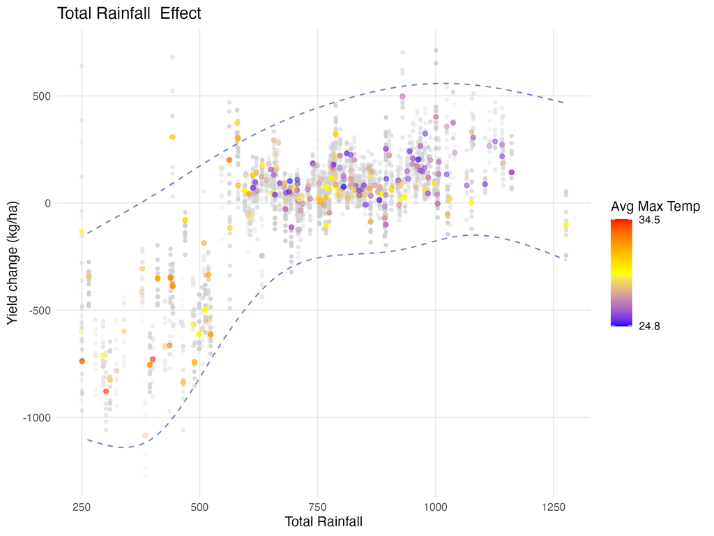

SHAP plot

### Performance Metrics Summary

```r
# Summarize bootstrap results for different datasets
# This creates summary statistics of model performance with confidence intervals
summarize_boots_performance(full_results, bootstrap_results, experiment, set = "train")
summarize_boots_performance(full_results, bootstrap_results, experiment, set = "test")
summarize_boots_performance(full_results, bootstrap_results, experiment, set = "oob")
```

## 4. Final Aggregation Across AEZs

After processing all individual AEZs, the script creates summary tables and visualizations that combine results across all zones:

```r
# In the full script, this happens after the AEZ loop completes

# Create model performance table across all AEZs
# This summarizes metrics like RMSE, R², MAE for each AEZ
performance_table <- create_performance_table(
  aez_list = AEZ_list,              # List of all AEZs
  experiment_t = experiment_t,      # Base experiment name
  base_dir = "model_output",        # Output directory
  N_obs_df = N_obs_df               # Number of observations per AEZ
)

# Create combined plot grid of predicted vs observed yields across AEZs
# This allows visual comparison of model performance across regions
combine_pred_obs_plots(
  experiment = experiment_t,
  aez_list = AEZ_list
)

# Save the final combined plots in different formats
ggsave(paste0('final_results/', experiment_t, '_scatter_plots.png'))
ggsave(
  paste0('final_results/', experiment_t, '_scatter_plots.pdf'),
  width = 180,
  height = 160,
  units = "mm",
  dpi = 300
)
```

# Key Functions in the Script

The script relies on numerous custom functions from external R files. Here are explanations of the core functions:

## 1. Data Preparation and Model Training

- `load_and_preprocess`: This function loads data from CSV files, removes outliers based on quantile thresholds, handles missing values using the specified imputation method, and prepares the data for modeling.
- `normalize_features`: Standardizes numeric features by subtracting the mean and dividing by the standard deviation. This ensures all features have comparable scales during analysis.
- `remap_formula`: Converts technical feature names to more readable names (e.g., “Rain.sum” → “Total_Rainfall”) in model formulas.
- `create_recipe`: Creates a tidymodels recipe for data preprocessing, handling categorical variables, standardization, and other transformations.
- `train_simple_rf`: Trains a Random Forest model with specified parameters (mtry, trees, min_n, max.depth) using the ranger engine.

## 2. Evaluation and Analysis

- `estimate_metrics_simple_rf`: Calculates performance metrics (RMSE, R², MAE) for models on training, test, and out-of-bag data.
- `calculate_variable_importance`: Determines feature importance using permutation-based methods, capturing how much model performance decreases when each feature is randomly shuffled.
- `compute_shap_values`: Calculates SHAP (SHapley Additive exPlanations) values for model interpretability, showing how each feature contributes to predictions for each observation.
- `estimate_ind_cv_performance`: Runs cross-validation to assess model performance variability and provide more robust feature importance estimates.

## 3. Uncertainty Quantification

- `plot_bootstrap_shap`: Creates SHAP plots with uncertainty bands derived from bootstrap resampling, showing how feature effects vary across bootstrap samples.
- `plot_bootstrap_shap_gamCI`: Enhances SHAP visualization with smoothed confidence intervals using Generalized Additive Models.
- `plot_bootstrap_shap_improved`: Creates visually enhanced SHAP plots with better aesthetics and more informative uncertainty visualization.
- `summarize_boots_performance`: Summarizes performance metrics across bootstrap iterations, calculating mean, standard deviation, and confidence intervals.

## 4. Visualization and Reporting

- `create_and_save_obs_pred_plot`: Creates scatter plots of observed vs. predicted yield values.
- `combine_pred_obs_plots`: Combines plots across AEZs for easy comparison.
- `plot_aez_distribution`: Visualizes the distribution of observations across different Agro-Ecological Zones.
- `create_performance_table`: Creates summary tables of model performance across all AEZs.

# SHAP Analysis

SHAP (SHapley Additive exPlanations) values explain model predictions by showing:

1. How much each feature contributes to pushing the prediction higher or lower
2. How feature effects vary across the feature range and interact with other features
3. Which features have the most significant overall impact on predictions
4. How reliable these effects are (when combined with bootstrap uncertainty)

The script creates multiple types of SHAP visualizations to explore these relationships from different angles.

# AEZ Comparison

By running the analysis separately for each AEZ, the script enables:

1. Comparison of model performance across different ecological zones
2. Identification of region-specific important features
3. Understanding how climate-yield relationships vary by region
4. Creation of targeted recommendations based on local conditions

This regional approach recognizes that agricultural systems function differently across environments, avoiding one-size-fits-all conclusions.

# Outputs and Interpretation

The script produces several types of outputs:

1. **Performance Metrics**: RMSE, R², and MAE for each model, with confidence intervals from bootstrapping.
2. **Feature Importance Rankings**: Which factors most strongly influence yield predictions, with uncertainty estimates.
3. **SHAP Interaction Plots**: How one feature’s effect changes based on another feature’s value (e.g., how the effect of rainfall varies with temperature).